# capstone

```python
import pandas as pd
import numpy as np
import matplotlib
import seaborn as sns
import matplotlib.pyplot as plt


%matplotlib inline
```

### functions to help in plotting

```python
# plots seaborn distribution plot
def distplot(feature,xlabel,ylabel):
    fig, ax = plt.subplots(figsize=(7, 7)) #controls the size of the plot
    ax= sns.distplot(data[feature],kde=False,bins=50) #plot the figure
    ax.set(xlabel=xlabel, ylabel=ylabel)  #controls the label on x and y axis

def histgram(feature , xlabel,ylabel,lim,bins):
    plt.figure(figsize=(7,7))
    data[feature].hist(bins=bins)
    plt.xlim(0,lim)     #controls the scale on x axis
    plt.title(feature)  #controls the title of the plot
    plt.xlabel(xlabel)  #controls the label on x axis
    plt.ylabel(ylabel)  #controls the label on y axis
    plt.show()

# plots the corrlation matrix
def plot_corr(data,size=10):
    corr = data.corr()   #gets the correlation table between features
    fig, ax = plt.subplots(figsize=(size, size))
    cmap = sns.diverging_palette( 220 , 90,60 , as_cmap = True ) #handls the coloring
    sns.heatmap(corr,ax=ax,cmap="coolwarm",annot = True, annot_kws = { 'fontsize' : 12 }) #plots the figure

# plots all columns except price, yearOfRegistration,powerPS and monthOfRegistration using countplot
def plotting_columns(data,columns):
    for column in columns:
        graph_columns = np.minimum(len(data[column].unique()),5)  #controls the number of bars plotted
        order = data[column].value_counts().iloc[:graph_columns].index #controls the order of attributes plotted
        fig, ax = plt.subplots(figsize=(10, 10))
        sns.countplot(x=column,data=data,order=order,ax=ax).set_title(column) #plots the figure
```

### Reading the data

```python
data = pd.read_csv("autos.csv",encoding='cp1252')
dataset_count=len(data)
```

### Printing the first 10 records

```python
display(data.head(n=10))
```

|  | dateCrawled | name | seller | offerType | price | abtest | vehicleType | yearOfRegistration | gearbox | powerPS | model | kilometer | monthOfRegistration | fuelType | brand | notRepairedDamage | dateCreated | nrOfPictures | postalCode | lastSeen |
| --- | --- | --- | --- | --- | --- | --- | --- | --- | --- | --- | --- | --- | --- | --- | --- | --- | --- | --- | --- | --- |
| 0 | 3/24/2016 11:52 | Golf_3_1.6 | privat | Angebot | 480.0 | test | NaN | 1993.0 | manuell | 0.0 | golf | 150000 | 0.0 | benzin | volkswagen | NaN | 3/24/2016 0:00 | 0.0 | 70435.0 | 4/7/2016 3:16 |
| 1 | 3/24/2016 10:58 | A5_Sportback_2.7_Tdi | privat | Angebot | 18300.0 | test | coupe | 2011.0 | manuell | 190.0 | NaN | 125000 | 5.0 | diesel | audi | ja | 3/24/2016 0:00 | 0.0 | 66954.0 | 4/7/2016 1:46 |
| 2 | 3/14/2016 12:52 | Jeep_Grand_Cherokee_"Overland" | privat | Angebot | 9800.0 | test | suv | 2004.0 | automatik | 163.0 | grand | 125000 | 8.0 | diesel | jeep | NaN | 3/14/2016 0:00 | 0.0 | 90480.0 | 4/5/2016 12:47 |
| 3 | 3/17/2016 16:54 | GOLF_4_1_4__3TÜRER | privat | Angebot | 1500.0 | test | kleinwagen | 2001.0 | manuell | 75.0 | golf | 150000 | 6.0 | benzin | volkswagen | nein | 3/17/2016 0:00 | 0.0 | 91074.0 | 3/17/2016 17:40 |
| 4 | 3/31/2016 17:25 | Skoda_Fabia_1.4_TDI_PD_Classic | privat | Angebot | 3600.0 | test | kleinwagen | 2008.0 | manuell | 69.0 | fabia | 90000 | 7.0 | diesel | skoda | nein | 3/31/2016 0:00 | 0.0 | 60437.0 | 4/6/2016 10:17 |
| 5 | 4/4/2016 17:36 | BMW_316i___e36_Limousine___Bastlerfahrzeug__Ex... | privat | Angebot | 650.0 | test | limousine | 1995.0 | manuell | 102.0 | 3er | 150000 | 10.0 | benzin | bmw | ja | 4/4/2016 0:00 | 0.0 | 33775.0 | 4/6/2016 19:17 |
| 6 | 4/1/2016 20:48 | Peugeot_206_CC_110_Platinum | privat | Angebot | 2200.0 | test | cabrio | 2004.0 | manuell | 109.0 | 2_reihe | 150000 | 8.0 | benzin | peugeot | nein | 4/1/2016 0:00 | 0.0 | 67112.0 | 4/5/2016 18:18 |
| 7 | 3/21/2016 18:54 | VW_Derby_Bj_80__Scheunenfund | privat | Angebot | 0.0 | test | limousine | 1980.0 | manuell | 50.0 | andere | 40000 | 7.0 | benzin | volkswagen | nein | 3/21/2016 0:00 | 0.0 | 19348.0 | 3/25/2016 16:47 |
| 8 | 4/4/2016 23:42 | Ford_C___Max_Titanium_1_0_L_EcoBoost | privat | Angebot | 14500.0 | control | bus | 2014.0 | manuell | 125.0 | c_max | 30000 | 8.0 | benzin | ford | NaN | 4/4/2016 0:00 | 0.0 | 94505.0 | 4/4/2016 23:42 |
| 9 | 3/17/2016 10:53 | VW_Golf_4_5_tuerig_zu_verkaufen_mit_Anhaengerk... | privat | Angebot | 999.0 | test | kleinwagen | 1998.0 | manuell | 101.0 | golf | 150000 | 0.0 | NaN | volkswagen | NaN | 3/17/2016 0:00 | 0.0 | 27472.0 | 3/31/2016 17:17 |

### printing some statistics

```python
data.describe()
```

|  | price | yearOfRegistration | powerPS | monthOfRegistration | nrOfPictures | postalCode |
| --- | --- | --- | --- | --- | --- | --- |
| count | 3.715380e+05 | 371537.000000 | 371538.000000 | 371537.000000 | 371537.0 | 371537.000000 |
| mean | 1.729544e+04 | 2004.577883 | 115.548840 | 5.734473 | 0.0 | 50820.666402 |
| std | 3.587905e+06 | 92.865496 | 192.137238 | 3.712383 | 0.0 | 25799.080292 |
| min | 0.000000e+00 | 1000.000000 | 0.000000 | 0.000000 | 0.0 | 1067.000000 |
| 25% | 1.150000e+03 | 1999.000000 | 70.000000 | 3.000000 | 0.0 | 30459.000000 |
| 50% | 2.950000e+03 | 2003.000000 | 105.000000 | 6.000000 | 0.0 | 49610.000000 |
| 75% | 7.200000e+03 | 2008.000000 | 150.000000 | 9.000000 | 0.0 | 71546.000000 |
| max | 2.147484e+09 | 9999.000000 | 20000.000000 | 12.000000 | 0.0 | 99998.000000 |

### looking at values of columns that are candidates to be dropped

```python
print(data.groupby('seller').size(),"\n\n")
print(data.groupby('offerType').size(),"\n\n")
print(data.groupby('abtest').size(),"\n\n")
print(data.groupby('nrOfPictures').size(),"\n\n")
```

```
seller
gewerblich         3
golf               1
privat        371534
dtype: int64


offerType
150000          1
Angebot    371525
Gesuch         12
dtype: int64


abtest
benzin          1
control    178946
test       192591
dtype: int64


nrOfPictures
0.0    371537
dtype: int64
```

*i will be keeping only the cars that were sold by private owenrs to create an accurate comparison

```python
data=data[data.seller=="privat"]
```

### dropping some columns

*seller column contains only one value (privat)

*both offertype and abtest columns have no relvance for the analysis

*nrofpictures column has no values

*columns last seen , postal code , datecreated and date crawled all have no relevance in predicting the price

so i will drop all columns mentioned

```python
data.drop(['seller', 'offerType', 'abtest', 'nrOfPictures','dateCrawled', 'dateCreated','postalCode','lastSeen' ], axis='columns', inplace=True)
```

### removing duplicates and NaNs

```python
data=data.drop_duplicates(['name','price','vehicleType','yearOfRegistration','gearbox','powerPS','model','kilometer','monthOfRegistration','fuelType','notRepairedDamage'])
data = data.dropna()
```

##### observing the correlation between the price column and the other columns

|  | price | yearOfRegistration | powerPS | monthOfRegistration |
| --- | --- | --- | --- | --- |
| price | 1.000000 | 0.010340 | 0.008564 | 0.004770 |
| yearOfRegistration | 0.010340 | 1.000000 | 0.100522 | 0.032599 |
| powerPS | 0.008564 | 0.100522 | 1.000000 | 0.014107 |
| monthOfRegistration | 0.004770 | 0.032599 | 0.014107 | 1.000000 |

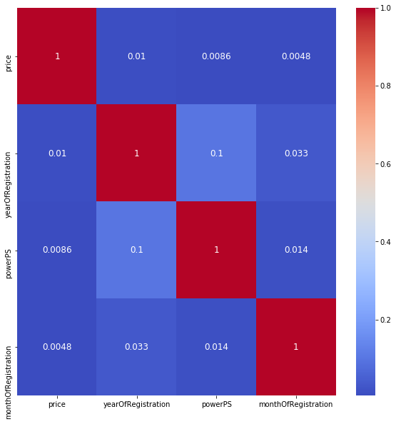

```python
plot_corr(data)
data.corr()
```

### observing the price column

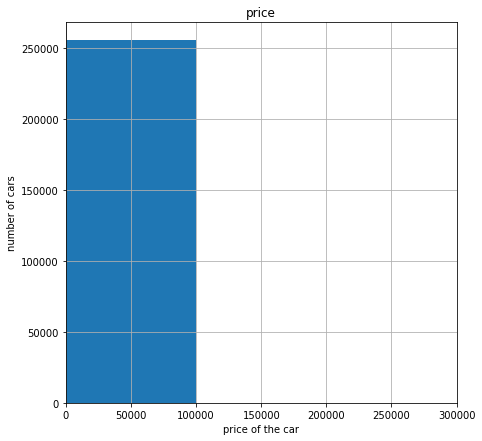

```python
histgram('price','price of the car','number of cars',300000,1000)
```

```python
print(len(data[data.price > 150000]))
```

```
112
```

*some people are overestimating their value of the car so i will cut the data at max of 150000

```python
data = data[data.price < 150000]
```

```python
print("number of cars with price 0 : ",len(data[data.price == 0]))
```

```
number of cars with price 0 :  3194
```

*some persons are giving their cars away for free so these rows will be removed

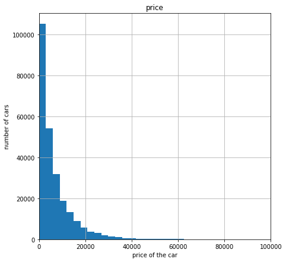

```python
data = data[data.price != 0]
histgram('price','price of the car','number of cars',100000,50)
```

```python
print("number of cars with price 0 : ",len(data[data.price == 0]))
```

```
number of cars with price 0 :  0
```

using log normalization method to normalize the data

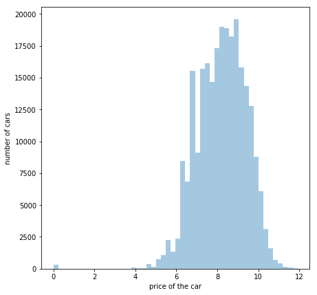

```python
data["price"]=np.log(data["price"])
distplot("price",'price of the car','number of cars')
```

### observing the year of regestration column

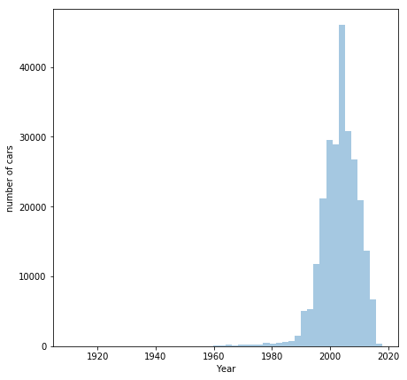

```python
distplot("yearOfRegistration",'Year','number of cars')
```

```python
print("number of cars registered before 1960 :",len(data[data.yearOfRegistration<1960]))
print("number of cars registered after  2016 :",len(data[data.yearOfRegistration>2016]))
```

```
number of cars registered before 1960 : 127
number of cars registered after  2016 : 10
```

*cars regiestered before 1960 or after 2016 will be removed as they are outliers

```python
data=data[(data.yearOfRegistration>=1960) & (data.yearOfRegistration<2017)]
```

using log normalization method to normalize the data

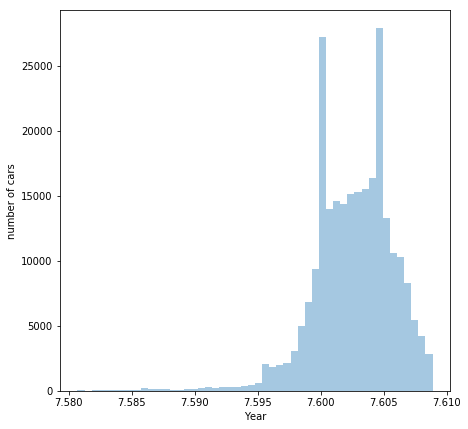

```python
data["yearOfRegistration"]=np.log(data["yearOfRegistration"])
distplot("yearOfRegistration",'Year','number of cars')
```

### observing the month of registration column

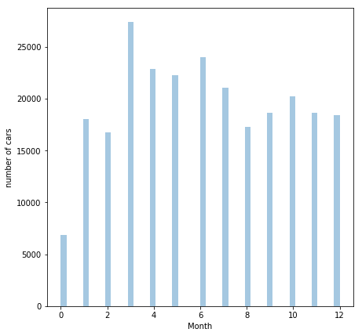

```python
distplot("monthOfRegistration",'Month','number of cars')
```

```python
print("number of cars with month of registration 0 : ",len(data[data.monthOfRegistration == 0]))
```

```
number of cars with month of registration 0 :  6847
```

there are some people that submitted month of registeration = 0 which is not valid so these people will be removed

```python
data = data[data.monthOfRegistration != 0]
```

[output not shown]

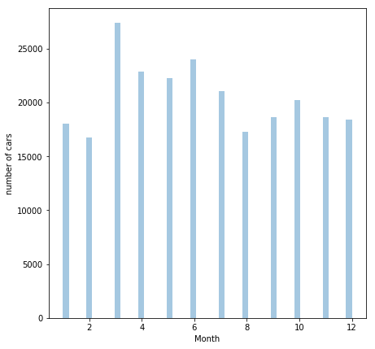

```python
print("number of month of registration 0 : ",len(data[data.monthOfRegistration == 0]))
distplot("monthOfRegistration",'Month','number of cars')
```

### observing the powerPS column

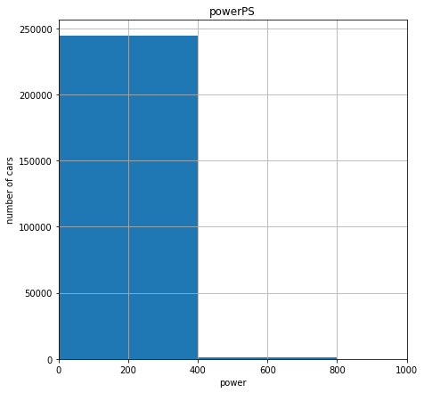

```python
# distplot("powerPS",50)
histgram('powerPS','power','number of cars',1000,50)
```

some cars have very low horse power and others have very high horse power which is not practical in both cases

so all cars with horse power less than or equal 5 or more than or equal 1000 are removed

```python
print("number of cars with power > 1000 : ",len(data[data.powerPS>1000]))
print("number of cars with power < 5    : ",len(data[data.powerPS<5]))
```

```
number of cars with power > 1000 :  116
number of cars with power < 5    :  7959
```

```python
data=data[(data.powerPS>5) & (data.powerPS<1000)]
```

using log normalization method to normalize the data

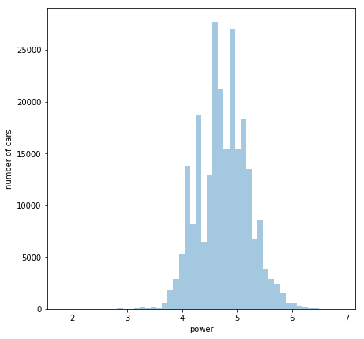

```python
data["powerPS"]=np.log(data["powerPS"])
distplot("powerPS",'power','number of cars')
```

##### handling the name column

since

*name column almost doesn't have a strong correlation at all with the price column

*name column refers to the advertising name of the car

*there is no standard convention for entering the name (each person enters the name the way he like), thus making it almost impossible to hot-encode the name column as it will consume alot of time and space and will not be worth it

thus i will be removing the name column

```python
data=data.drop('name',axis='columns', inplace=False)
```

### plotting all the other columns

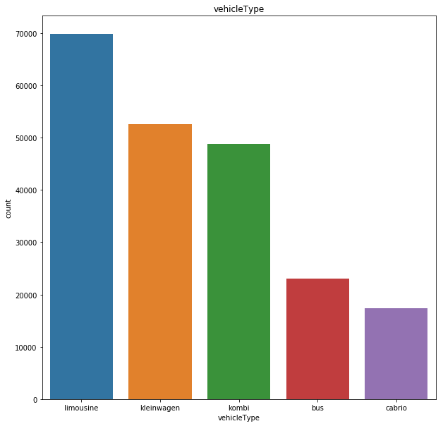

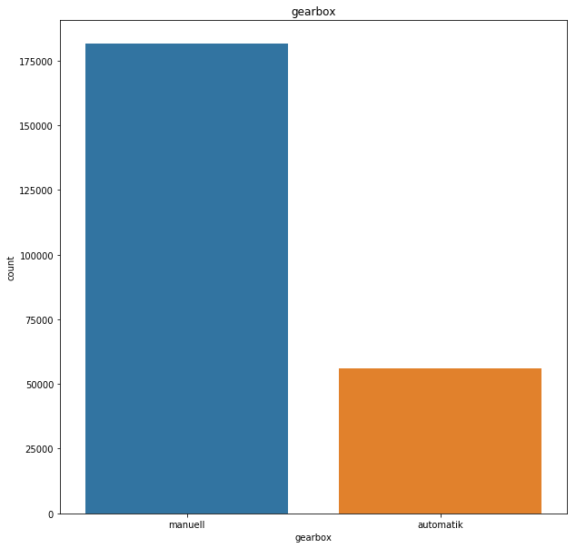

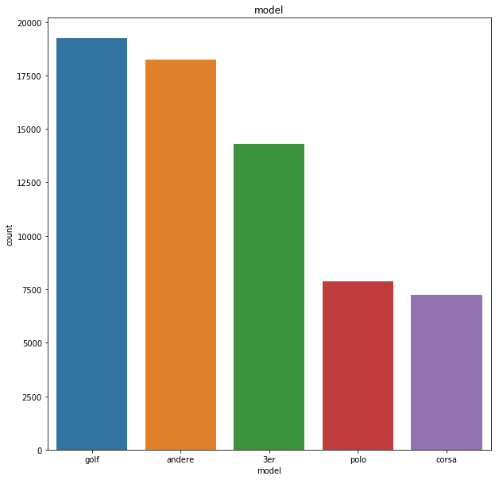

[figure not shown]

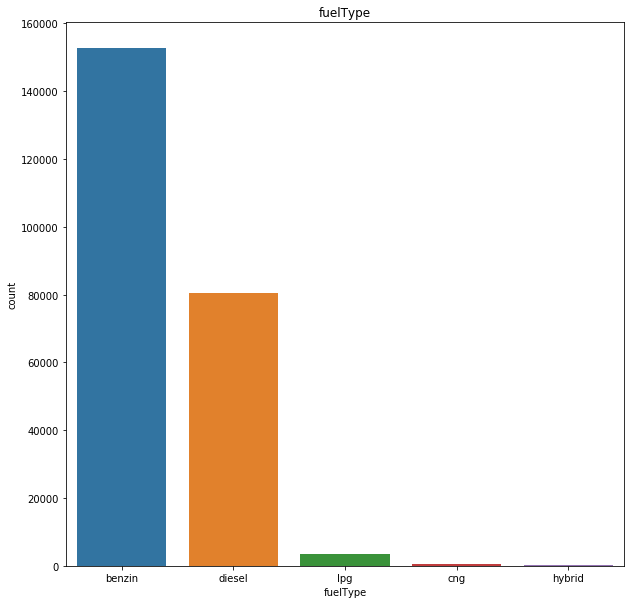

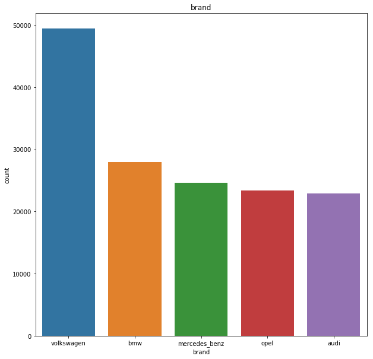

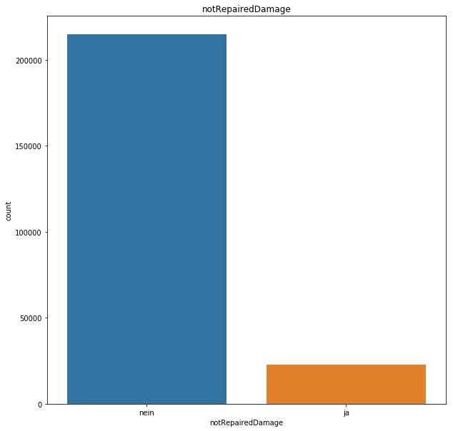

```python
data_columns=list(data)
for column in data_columns:
    if (column in ['price','yearOfRegistration','powerPS','monthOfRegistration']):
        data_columns.remove(column)
# i used countplot instead of distplot to save processing time
plotting_columns(data,data_columns)
```

### using correlation plots to observe the correlation between features after cleaning the data

```
array([[<matplotlib.axes._subplots.AxesSubplot object at 0x000002AA2E894B38>,
      dtype=object)
```

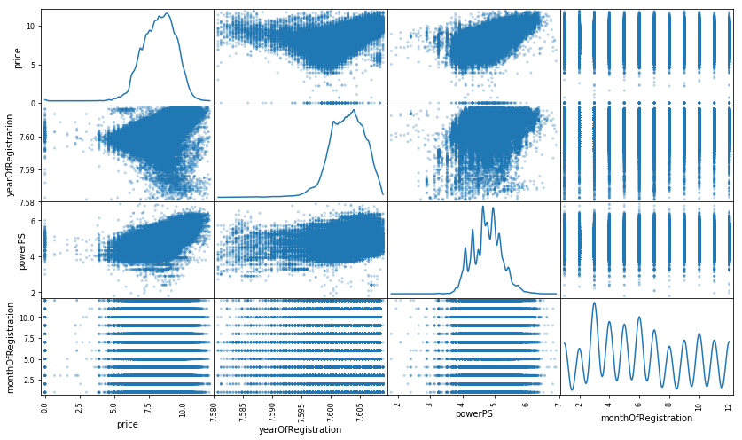

```python
pd.scatter_matrix(data, alpha = 0.3, figsize = (14,8), diagonal = 'kde')
```

|  | price | yearOfRegistration | powerPS | monthOfRegistration |
| --- | --- | --- | --- | --- |
| price | 1.000000 | 0.596721 | 0.564636 | 0.012458 |
| yearOfRegistration | 0.596721 | 1.000000 | 0.241431 | -0.005998 |
| powerPS | 0.564636 | 0.241431 | 1.000000 | 0.012958 |
| monthOfRegistration | 0.012458 | -0.005998 | 0.012958 | 1.000000 |

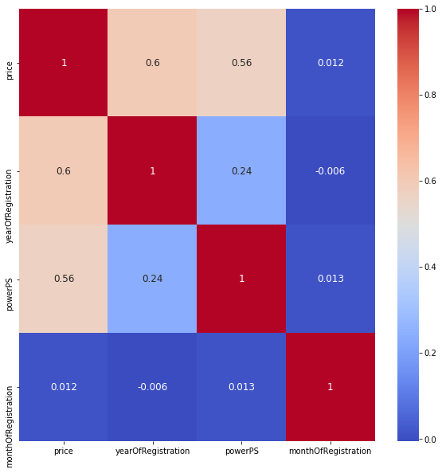

```python
plot_corr(data)
data.corr()
```

### observing some satistics about the cleaned data

```python
data.describe()
```

|  | price | yearOfRegistration | powerPS | monthOfRegistration |
| --- | --- | --- | --- | --- |
| count | 237332.000000 | 237332.000000 | 237332.000000 | 237332.000000 |
| mean | 8.256215 | 7.602687 | 4.763463 | 6.361864 |
| std | 1.164885 | 0.003155 | 0.448051 | 3.350210 |
| min | 0.000000 | 7.580700 | 1.791759 | 1.000000 |
| 25% | 7.438384 | 7.600902 | 4.454347 | 3.000000 |
| 50% | 8.294050 | 7.602900 | 4.753590 | 6.000000 |
| 75% | 9.103868 | 7.604894 | 5.075174 | 9.000000 |
| max | 11.911702 | 7.608871 | 6.906755 | 12.000000 |

### one hot encoding the all categorical features

Encode categorical features as a numeric array.

```python
categorical = ['vehicleType', 'gearbox', 'model', 'fuelType','brand','notRepairedDamage']
encoded = pd.get_dummies(data[categorical])
data=data.drop(categorical,axis='columns', inplace=False)
data=data.join(encoded)
display(data.head(n=5))
```

|  | price | yearOfRegistration | powerPS | kilometer | monthOfRegistration | vehicleType_andere | vehicleType_bus | vehicleType_cabrio | vehicleType_coupe | vehicleType_kleinwagen | ... | brand_skoda | brand_smart | brand_subaru | brand_suzuki | brand_toyota | brand_trabant | brand_volkswagen | brand_volvo | notRepairedDamage_ja | notRepairedDamage_nein |
| --- | --- | --- | --- | --- | --- | --- | --- | --- | --- | --- | --- | --- | --- | --- | --- | --- | --- | --- | --- | --- | --- |
| 3 | 7.313220 | 7.601402 | 4.317488 | 150000 | 6.0 | 0 | 0 | 0 | 0 | 1 | ... | 0 | 0 | 0 | 0 | 0 | 0 | 1 | 0 | 0 | 1 |
| 4 | 8.188689 | 7.604894 | 4.234107 | 90000 | 7.0 | 0 | 0 | 0 | 0 | 1 | ... | 1 | 0 | 0 | 0 | 0 | 0 | 0 | 0 | 0 | 1 |
| 5 | 6.476972 | 7.598399 | 4.624973 | 150000 | 10.0 | 0 | 0 | 0 | 0 | 0 | ... | 0 | 0 | 0 | 0 | 0 | 0 | 0 | 0 | 1 | 0 |
| 6 | 7.696213 | 7.602900 | 4.691348 | 150000 | 8.0 | 0 | 0 | 1 | 0 | 0 | ... | 0 | 0 | 0 | 0 | 0 | 0 | 0 | 0 | 0 | 1 |
| 10 | 7.600902 | 7.602900 | 4.653960 | 150000 | 12.0 | 0 | 0 | 0 | 0 | 0 | ... | 0 | 0 | 0 | 0 | 0 | 0 | 0 | 0 | 0 | 1 |

5 rows × 313 columns

### dropping the price column

```python
price = data['price']
features= data.drop(['price'], axis='columns', inplace=False)
```

### splitting data into testing and training sets

```python
from sklearn.model_selection import train_test_split
X_train, X_test, y_train, y_test = train_test_split(features, price, test_size=0.2, random_state = 42)
print("Training set has {} samples.".format(X_train.shape[0]))
print("Testing set has {} samples.".format(X_test.shape[0]))
```

```
Training set has 189865 samples.
Testing set has 47467 samples.
```

## trying different supervised models

###### all imports needed

```python
from sklearn.ensemble import RandomForestRegressor
from sklearn.model_selection import GridSearchCV,cross_val_predict,cross_validate
from sklearn.metrics import r2_score,make_scorer
from sklearn.linear_model import LinearRegression
```

##### linear regression

```python
linear_regression =LinearRegression() #intiallizing the model
linear_regression.fit(X_train,y_train) #fitting the model to the training sets
linear_regression_predicted = linear_regression.predict(X_test) #making the model predict the values of the testing set X
```

using r2_score to measure the accuracy of the linear regression model

```python
#calculating the error between the values predicted by the model and the actual set
print( r2_score(y_test,linear_regression_predicted))
```

```
0.7442175619707079
```

##### random forest with no parameter tuning

```python
random_forest_model = RandomForestRegressor(random_state=42)  #intiallizing the model
random_forest_model.fit(X_train,y_train)#fitting the model to the training sets
random_forest_predicted =random_forest_model.predict(X_test) #making the model predict the values of the testing set X
```

using r2_score to measure the accuracy of the unoptimized model

```python
#calculating the error between the values predicted by the model and the actual set
print( r2_score(y_test,random_forest_predicted))
```

```
0.822267836153981
```

#### Random Forest

with the help of grid search technique in parameter tuning

```python
random_forest_model = RandomForestRegressor(random_state=42)
#set of the parameters that the grid search technique will create all possible combinations from
parameters = {
     "n_estimators": [10,100],
    "criterion" : ["mse"],
    'min_samples_leaf':[1,2],
    'min_samples_split':[2,4]

}
#intiallizing the gridsearch object with the random forest model and setting verbose to print the process steps
grid_obj = GridSearchCV(random_forest_model, parameters,verbose=2)
#fitting the gridsearch object with the training sets
grid_fit = grid_obj.fit(X_train, y_train)
#getting the best model
best_model = grid_fit.best_estimator_
#letting the best predict the values of X_test
best_predictions = best_model.predict(X_test)
```

```
Fitting 3 folds for each of 8 candidates, totalling 24 fits
[CV] criterion=mse, min_samples_leaf=1, min_samples_split=2, n_estimators=10
```

```
[CV]  criterion=mse, min_samples_leaf=1, min_samples_split=2, n_estimators=10, total=  31.8s
[CV] criterion=mse, min_samples_leaf=1, min_samples_split=2, n_estimators=10
```

```
[Parallel(n_jobs=1)]: Done   1 out of   1 | elapsed:   34.7s remaining:    0.0s
```

[output not shown]

```
[Parallel(n_jobs=1)]: Done  24 out of  24 | elapsed: 58.1min finished
```

using r2_score to measure the accuracy of the random forest

```python
#calculating the error between the values predicted by the model and the actual set
print("Final r2_score on the testing data: ",r2_score(y_test, best_predictions))
```

```
Final r2_score on the testing data:  0.8436978179652436
```

optimized parameters

```python
#getting the best parameters that have the highest accuracy
best_params = grid_obj.best_params_
print(best_params)
```

```
{'criterion': 'mse', 'min_samples_leaf': 2, 'min_samples_split': 2, 'n_estimators': 100}
```

### sensitivity analysis

```python
optimized_random_forest = RandomForestRegressor(criterion=best_params['criterion'],
                                               min_samples_leaf = best_params['min_samples_leaf'],
                                               min_samples_split = best_params['min_samples_split'],
                                               n_estimators= best_params['n_estimators'])
optimized_random_forest.fit(X_train,y_train)
```

```
RandomForestRegressor(bootstrap=True, criterion='mse', max_depth=None,
           max_features='auto', max_leaf_nodes=None,
           min_impurity_decrease=0.0, min_impurity_split=None,
           min_samples_leaf=2, min_samples_split=2,
           min_weight_fraction_leaf=0.0, n_estimators=100, n_jobs=None,
           oob_score=False, random_state=None, verbose=0, warm_start=False)
```

viewing feature importance

```python
feature_names = list(data)
feature_names.remove('price')
importances = optimized_random_forest.feature_importances_
for name, importance in zip(feature_names,importances  ):
    print(name, "=", importance)
```

```
yearOfRegistration = 0.5841255148197091
powerPS = 0.21527976130977677
kilometer = 0.020877695279005924
monthOfRegistration = 0.027393963222354413
vehicleType_andere = 0.0005222422377044331
vehicleType_bus = 0.0014103591976969442
vehicleType_cabrio = 0.010237195864509462
vehicleType_coupe = 0.001667177455724692
vehicleType_kleinwagen = 0.003417847591861425
vehicleType_kombi = 0.0032812324583839903
vehicleType_limousine = 0.002864612756002142
vehicleType_suv = 0.0031334627581075243
gearbox_automatik = 0.002026762508170792
gearbox_manuell = 0.0019650338612905932
model_100 = 8.753859238188485e-05
model_145 = 4.5214771588062375e-06
model_147 = 5.373435407592533e-05
model_156 = 0.00030415929642122055
model_159 = 4.164847690354861e-05
model_1_reihe = 9.849093299169654e-05
model_1er = 0.00022573923976333058
model_200 = 5.1865460757805434e-08
model_2_reihe = 0.0003443938620422048
model_300c = 3.758602302540952e-06
model_3_reihe = 0.00030137348221808053
model_3er = 0.0018048056238633328
model_4_reihe = 5.849488549931427e-05
model_500 = 7.127356780171071e-05
model_5_reihe = 1.7262730122209424e-05
model_5er = 0.0004889249236913923
model_601 = 2.3728991295752824e-05
model_6_reihe = 0.00010113049927845205
model_6er = 2.4299672536574112e-05
model_7er = 0.00016856607310192231
model_80 = 0.00019672990424397067
model_850 = 2.7213031565077902e-05
model_90 = 1.813146964954015e-05
model_900 = 3.078082376145737e-05
model_9000 = 3.259645273221177e-06
model_911 = 0.004493039939974342
```

[output cut: 257 more lines]

```
brand_porsche = 0.0009359961837193432
brand_renault = 0.0013691071315098903
brand_rover = 0.00014902374092013506
brand_saab = 0.0002127369809205024
brand_seat = 0.0004902238061346385
brand_skoda = 0.00035204408919335044
brand_smart = 0.0003373302398118604
brand_subaru = 0.00013438100192967776
brand_suzuki = 0.00021332897509534056
brand_toyota = 0.0006574920428439892
brand_trabant = 9.43864849532863e-05
brand_volkswagen = 0.0068582868835001375
brand_volvo = 0.0003404748643208682
notRepairedDamage_ja = 0.012336522501846994
notRepairedDamage_nein = 0.024674453828987544
```

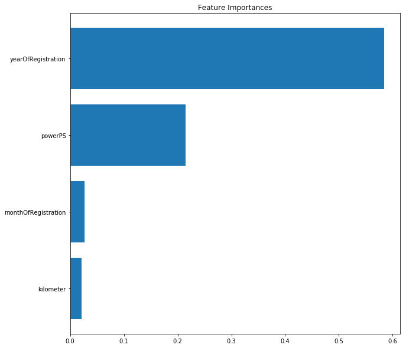

```python
indices = np.argsort(importances[:4])
plt.figure(figsize=(10,10))
plt.title('Feature Importances')
plt.barh(range(len(indices)), importances[indices])
plt.yticks(range(len(indices)), [feature_names[i] for i in indices])
plt.show()
```